# Project 2

## Randomization Test!

I want to know if there is an association with the `Genre` of game and `TotalEarnings` for the prize pool, specifically for the `Genre`s: Battle Royale and Multiplayer Online Battle Arena since they are the two highest prized genres. So I want to test whether there was a difference in mean `TotalEarnings` between the two Genres.

*Null hypothesis* : There is no difference in the mean TotalEarnings between Battle Royale and Multiplayer Online Battle Arena.

*Alternative hypothesis* : There is a significant difference in the mean TotalEarnings between Battle Royale and Multiplayer Online Battle Arena.

```r
esport %>% group_by(Genre) %>% summarize(n=mean(TotalEarnings))
```

```
## # A tibble: 11 x 2
##    Genre                                   n
##  * <fct>                               <dbl>
##  1 Battle Royale                   11973998.
##  2 Collectible Card Game            2142825.
##  3 Fighting Game                     128612.
##  4 First-Person Shooter             2309818.
##  5 Multiplayer Online Battle Arena 17728953.
##  6 Puzzle Game                         3595.
##  7 Racing                            179112.
##  8 Role-Playing Game                1062992.
##  9 Sports                            452252.
## 10 Strategy                         1368985.
## 11 Third-Person Shooter              688998.
```

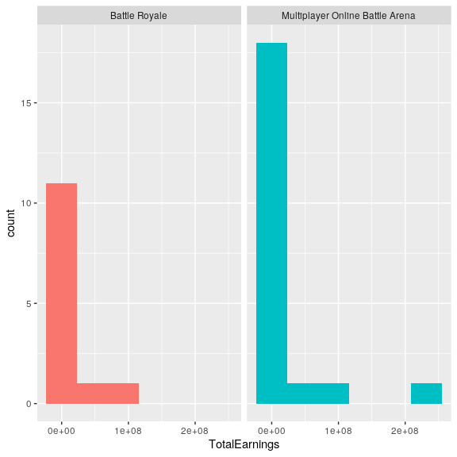

```r
br <- esport %>% filter(Genre=="Battle Royale") %>% select(Genre,TotalEarnings)
moba <- esport %>% filter(Genre=="Multiplayer Online Battle Arena") %>% select(Genre,TotalEarnings)

comp <- rbind(br,moba)
ggplot(comp,aes(TotalEarnings,fill=Genre))+geom_histogram(bins=6.5)+
facet_wrap(~Genre,ncol=2)+theme(legend.position="none")
```

```r
rand_dist<-vector()
for(i in 1:5000){
  new<-data.frame(te=sample(comp$TotalEarnings),genre=comp$Genre)
  rand_dist[i]<-mean(new[new$genre=="Battle Royale",]$te)-
  mean(new[new$genre=="Multiplayer Online Battle Arena",]$te)}
diffmeans <- esport %>% group_by(Genre) %>% filter(Genre=="Battle Royale" | Genre=="Multiplayer Online Battle Arena") %>% summarize(means=mean(TotalEarnings))
11973998- 17728953
```

```
## [1] -5754955
```

```r
diffmeans
```

```
## # A tibble: 2 x 2
##   Genre                               means
##   <fct>                               <dbl>
## 1 Battle Royale                   11973998.
## 2 Multiplayer Online Battle Arena 17728953.
```

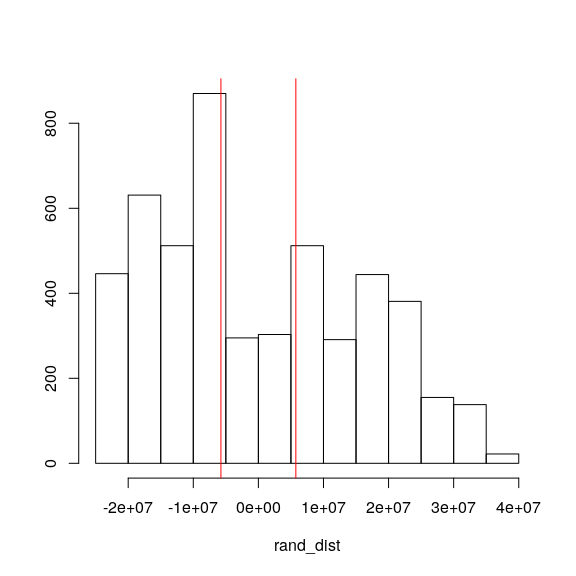

```r
{hist(rand_dist,main="",ylab=""); abline(v = c(-5754955, 5754955),col="red")}
```

```r
mean(rand_dist>5754955 | rand_dist < -5754955)
```

```
## [1] 0.847
```

```r
t.test(data=comp,TotalEarnings~Genre)
```

```
##
## Welch Two Sample t-test
##
## data: TotalEarnings by Genre
## t = -0.41304, df = 31.658, p-value = 0.6824
## alternative hypothesis: true difference in means is not
equal to 0
## 95 percent confidence interval:
## -34147896 22637987
## sample estimates:
## mean in group Battle Royale mean in group Multiplayer
Online Battle Arena
## 11973998 17728953
```

The randomization test has less power so the p-value is higher. The high p-value suggests that there is no significant difference in means. There is high variance in the difference in means.

## Linear Regression Modelling!

```r
esport$TotalEarnings_c = esport$TotalEarnings-mean(esport$TotalEarnings, na.rm=T)
esport$OnlineEarnings_c = esport$OnlineEarnings-mean(esport$OnlineEarnings, na.rm=T)

fit <- lm(TotalPlayers~TotalEarnings_c*OnlineEarnings_c,data=esport)
```

## Interpreting Coefficients!

```r
summary(fit)
```

```
##
## Call:
## lm(formula = TotalPlayers ~ TotalEarnings_c *
OnlineEarnings_c,
## data = esport)
##
## Residuals:
## Min 1Q Median 3Q Max
## -2836.7 -41.3 -35.3 -1.4 5103.0
##
## Coefficients:
## Estimate Std. Error t value Pr(>|t|)
## (Intercept) 2.676e+02 1.688e+01 15.853 < 2e-16 ***
## TotalEarnings_c 6.066e-05 6.762e-06 8.971 < 2e-16 ***
## OnlineEarnings_c 8.034e-05 1.097e-05 7.324 9.35e-13 ***
## TotalEarnings_c:OnlineEarnings_c -5.479e-13 2.483e-14
-22.067 < 2e-16 ***
## ---
## Signif. codes: 0 '***' 0.001 '**' 0.01 '*' 0.05 '.' 0.1
' ' 1
##
## Residual standard error: 376.8 on 516 degrees of freedom
## Multiple R-squared: 0.788, Adjusted R-squared: 0.7867
## F-statistic: 639.2 on 3 and 516 DF, p-value: < 2.2e-16
```

The intercept is 267.6, which suggests that a tournament with mean `TotalEarnings` and mean `OnlineEarnings` will have about 267-268 players. The coefficient for `TotalEarnings_c` means that for every $1 increase in mean prize money, there will be an increase of 6.066e-05 of a player. The coefficient for `OnlineEarnings_c` means that for every $1 increase in mean prize money, there will be 8.034e-05 of a player. The interaction of `TotalEarnings_c` and `OnlineEarnings_c` suggests that there is a decrease of -5.479e-13 of a player for every $1 increase in both `TotalEarnings_c` and `OnlineEarnings_c`.

Below mean `OnlineEarnings_c` leads to an increase in the slope of total earnings and players. Above mean `OnlineEarnings_c`leads to a decrease in the slope of `TotalEarnings_c` and `TotalPlayers`. It is interesting to see that below mean `OnlineEarnings_c` has the steepest slope, followed by the mean `OnlineEarnings_c`and then above the mean `OnlineEarnings_c.

## Plotting Linear Regression!

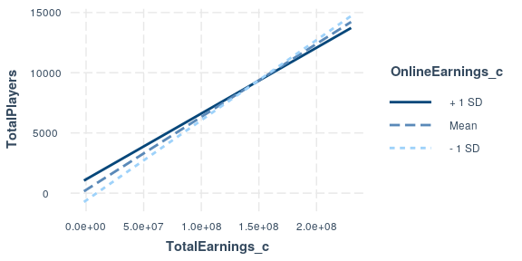

```r
library(interactions)
interact_plot(fit,pred =  TotalEarnings_c, modx = OnlineEarnings_c)
```

The coefficient of determination, R-squared, is the proportion of the variation that explained by the regression. Multiple R-squared: 0.788, Adjusted R-squared: 0.7867. Thus, this linear model accounts for about 78% of the variation in the data.

## Checking Assumptions!

Check assumptions of linearity, normality, and homoscedasticity graphically.

## Linearity?

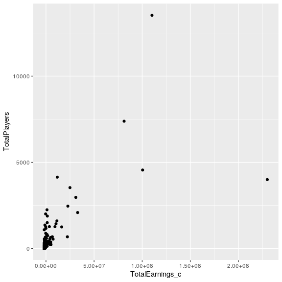

```r
esport %>% ggplot(aes(TotalEarnings_c,TotalPlayers)) + geom_point()
```

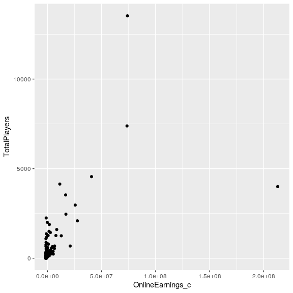

```r
esport %>% ggplot(aes(OnlineEarnings_c,TotalPlayers)) + geom_point()
```

It is a little hard to tell because of the outliers. But it looks like both predictors, `TotalEarnings` and `OnlineEarnings` should probably fail the linearity assumption. There is a hint of slight linearity but is hard to tell with the outliers.

## Normality?

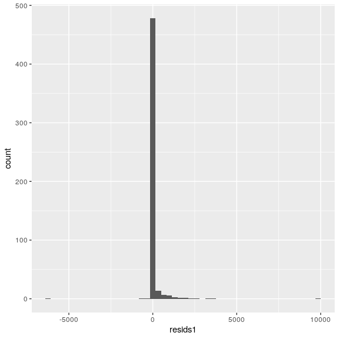

```r
resids1 <- lm(TotalPlayers~OnlineEarnings, data=esport)$residuals
ggplot()+geom_histogram(aes(resids1),bins=50)
```

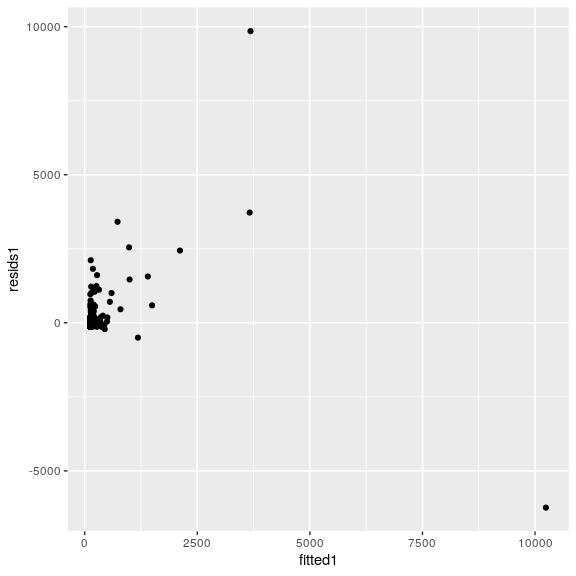

```r
fitted1<-lm(TotalPlayers~OnlineEarnings, data=esport)$fitted.values
ggplot()+geom_point(aes(fitted1,resids1))
```

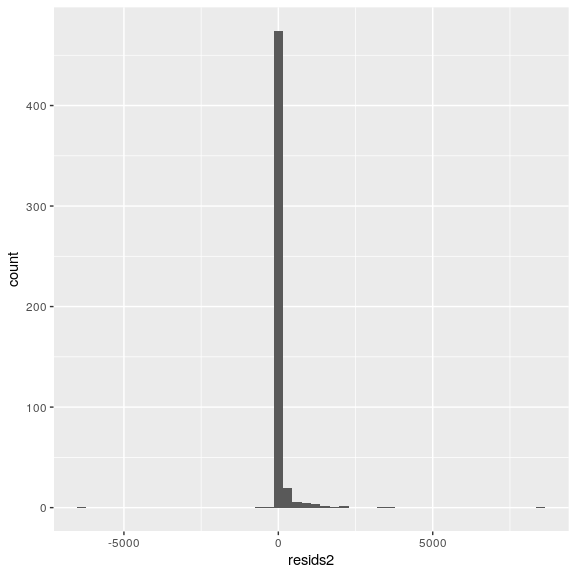

```r
resids2<- lm(TotalPlayers~TotalEarnings, data=esport)$residuals
ggplot()+geom_histogram(aes(resids2),bins=50)
```

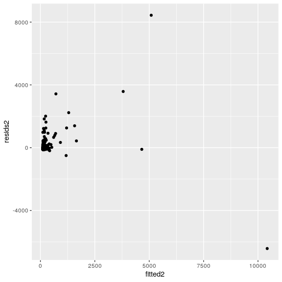

```r
fitted2<-lm(TotalPlayers~TotalEarnings, data=esport)$fitted.values
ggplot()+geom_point(aes(fitted2,resids2))
```

The histograms are really skewed for both predictors so they do not look normal. It looks like there is large variance in residuals for both predictors as well.

## Homoscedasticity?

```r
library(sandwich)
library(lmtest)
fit<-lm(TotalPlayers~TotalEarnings_c*OnlineEarnings_c,data=esport)
bptest(fit) #H0: homoskedastic
```

```
##
##  studentized Breusch-Pagan test
##
## data:  fit
## BP = 274.77, df = 3, p-value < 2.2e-16
```

```r
coeftest(fit, vcov = vcovHC(fit))[,1:2]
```

```
## Estimate Std. Error
## (Intercept) 2.675866e+02 8.187437e+01
## TotalEarnings_c 6.065886e-05 2.007101e-04
## OnlineEarnings_c 8.033622e-05 2.473643e-04
## TotalEarnings_c:OnlineEarnings_c -5.479117e-13
1.118232e-12
```

The calculated p value for Breusch-Pagan (bp) test is < 2.2e-16, which we can reject the null that the data is homoscedastic. Thus, the data is not homoscedastic but heteroscedastic.

The data fails all assumptions…

## Recomputing Regression!

Need Heteroscedasticity Robust Standard Errors and Bootstrapped SEs.

```r
coeftest(fit)
```

```
##
## t test of coefficients:
##
## Estimate Std. Error t value Pr(>|t|)
## (Intercept) 2.6759e+02 1.6879e+01 15.8531 < 2.2e-16 ***
## TotalEarnings_c 6.0659e-05 6.7615e-06 8.9712 < 2.2e-16
***
## OnlineEarnings_c 8.0336e-05 1.0970e-05 7.3235 9.348e-13
***
## TotalEarnings_c:OnlineEarnings_c -5.4791e-13 2.4829e-14
-22.0674 < 2.2e-16 ***
## ---
## Signif. codes: 0 '***' 0.001 '**' 0.01 '*' 0.05 '.' 0.1
' ' 1
```

```r
coeftest(fit, vcov=vcovHC(fit))
```

```
##
## t test of coefficients:
##
## Estimate Std. Error t value Pr(>|t|)
## (Intercept) 2.6759e+02 8.1874e+01 3.2683 0.001154 **
## TotalEarnings_c 6.0659e-05 2.0071e-04 0.3022 0.762605
## OnlineEarnings_c 8.0336e-05 2.4736e-04 0.3248 0.745488
## TotalEarnings_c:OnlineEarnings_c -5.4791e-13 1.1182e-12
-0.4900 0.624356
## ---
## Signif. codes: 0 '***' 0.001 '**' 0.01 '*' 0.05 '.' 0.1
' ' 1
```

The original model said that all coefficents were significant in the regression. After using Robust SE, we see that only the intercept remains significant at the 0.01 level. The SE increased from the original to the Robust SE.

## Bootstrap SE!

```r
set.seed(1234)
boot_dat<- sample_frac(esport, replace=T)

samp_distn<-replicate(5000, {
boot_dat <- sample_frac(esport, replace=T)
fit <- lm(TotalPlayers~TotalEarnings_c*OnlineEarnings_c, data=boot_dat)
coef(fit)
})
samp_distn %>% t %>% as.data.frame %>% summarize_all(sd)
```

```
## (Intercept) TotalEarnings_c OnlineEarnings_c
TotalEarnings_c:OnlineEarnings_c
## 1 42.47318 0.0001013776 0.0001257641 7.651835e-13
```

```r
samp_distn %>% t %>% as.data.frame %>% pivot_longer(1:4) %>% group_by(name) %>%
summarize(lower=quantile(value,.025), upper=quantile(value,.975))
```

```
## # A tibble: 4 x 3
##   name                                 lower    upper
## * <chr>                                <dbl>    <dbl>
## 1 (Intercept)                       1.61e+ 2 3.35e+ 2
## 2 OnlineEarnings_c                 -2.53e- 4 1.82e- 4
## 3 TotalEarnings_c                  -4.45e- 5 3.07e- 4
## 4 TotalEarnings_c:OnlineEarnings_c -2.78e-12 9.74e-13
```

## Logistic Regression Modelling!

I want to see how well a logistic model can predict a “highly prized game”. I define this by a game whose TotalEarnings are greater than 10,000 USD.

```r
esportb <- esport %>% mutate(y = ifelse(TotalEarnings>10000,1,0))
esportb <- esportb %>% filter(Genre != "Role-Playing Game")
esportb %>% group_by(Genre) %>% summarize(n())
```

```
## # A tibble: 10 x 2
##    Genre                           `n()`
##  * <fct>                           <int>
##  1 Battle Royale                      13
##  2 Collectible Card Game              17
##  3 Fighting Game                     164
##  4 First-Person Shooter              106
##  5 Multiplayer Online Battle Arena    21
##  6 Puzzle Game                        14
##  7 Racing                             52
##  8 Sports                             68
##  9 Strategy                           51
## 10 Third-Person Shooter                8
```

```r
lrm <- glm(y~ Genre + TotalTournaments, data=esportb, family="binomial")
coeftest(lrm)
```

```
##
## z test of coefficients:
##
## Estimate Std. Error z value Pr(>|z|)
## (Intercept) 0.601096 0.835499 0.7194 0.4718664
## GenreCollectible Card Game -2.123686 1.101444 -1.9281
0.0538436 .
## GenreFighting Game -2.946988 0.875597 -3.3657 0.0007635
***
## GenreFirst-Person Shooter -0.739829 0.878901 -0.8418
0.3999192
## GenreMultiplayer Online Battle Arena -0.764863 1.038496
-0.7365 0.4614201
## GenrePuzzle Game -3.502153 1.182569 -2.9615 0.0030617 **
## GenreRacing -0.633730 0.897609 -0.7060 0.4801756
## GenreSports -0.225241 0.887056 -0.2539 0.7995578
## GenreStrategy -1.060934 0.907835 -1.1686 0.2425478
## GenreThird-Person Shooter 0.234720 1.392707 0.1685
0.8661621
## TotalTournaments 0.185386 0.025262 7.3386 2.159e-13 ***
## ---
## Signif. codes: 0 '***' 0.001 '**' 0.01 '*' 0.05 '.' 0.1
' ' 1
```

```r
exp(coef(lrm))
```

```
## (Intercept) GenreCollectible Card Game
## 1.82411738 0.11959001
## GenreFighting Game GenreFirst-Person Shooter
## 0.05249758 0.47719567
## GenreMultiplayer Online Battle Arena GenrePuzzle Game
## 0.46539754 0.03013245
## GenreRacing GenreSports
## 0.53060890 0.79832405
## GenreStrategy GenreThird-Person Shooter
## 0.34613226 1.26455515
## TotalTournaments
## 1.20368262
```

logodds = 0.601096 + Collectible Card Game(-2.123686) + Fighting Game(-2.946988) + First-Person Shooter(-0.739829) + Multiplayer Online Battle Arena(-0.764863) + Puzzle Game(-3.502153) + Racing(-0.633730) + Sports(-0.225241) + Strategy(-1.060934) + Third-Person Shooter(0.234720) + TotalTournaments(0.185386)

Battle Royale is the `Genre` used as reference. The odds of Battle Royale to Collectible Card Game is 0.11959001. The odds of Battle Royale to Fighting Game is 0.05249758. As we continue this interpretation for the rest of the different `Genre`s, it is obvious that all Genres but 1, Third-Person Shooter, have less odds of being a highly prized game than the reference `Genre`: Battle Royale.

An increase in 1 `TotalTournaments` affects the logodds by an increase of 0.185386. So the odds of a tournament being highly prized is increased by 1.20368262.

Note: ended up removing Role-Playing Game from Genre to improve model.

## Confusion Matrix!

```r
prob <- predict(lrm,type="response")
table(predict=as.numeric(prob>.5),truth=esportb$y)%>%addmargins
```

```
##        truth
## predict   0   1 Sum
##     0   132  26 158
##     1    59 297 356
##     Sum 191 323 514
```

```r
class_diag<-function(probs,truth){

  tab<-table(factor(probs>.5,levels=c("FALSE","TRUE")),truth)
  acc=sum(diag(tab))/sum(tab)
  sens=tab[2,2]/colSums(tab)[2]
  spec=tab[1,1]/colSums(tab)[1]
  ppv=tab[2,2]/rowSums(tab)[2]

  if(is.numeric(truth)==FALSE & is.logical(truth)==FALSE) truth<-as.numeric(truth)-1

  #CALCULATE EXACT AUC
  ord<-order(probs, decreasing=TRUE)
  probs <- probs[ord]; truth <- truth[ord]

  TPR=cumsum(truth)/max(1,sum(truth))
  FPR=cumsum(!truth)/max(1,sum(!truth))

  dup<-c(probs[-1]>=probs[-length(probs)], FALSE)
  TPR<-c(0,TPR[!dup],1); FPR<-c(0,FPR[!dup],1)

  n <- length(TPR)
  auc<- sum( ((TPR[-1]+TPR[-n])/2) * (FPR[-1]-FPR[-n]) )

  data.frame(acc,sens,spec,ppv,auc)
}
class_diag(prob,esportb$y)
```

```
##         acc      sens      spec       ppv       auc
## 1 0.8346304 0.9195046 0.6910995 0.8342697 0.8969089
```

The Accuracy is 0.8346304. The Sensitivity (TPR) is 0.9195046. The Specificity (TNR) is 0.6910995. The Precision (PPV) is 0.8342697. The AUC is 0.8969089. This means that this is a good model for predicting if the game is having `TotalEarnings` > 10000.

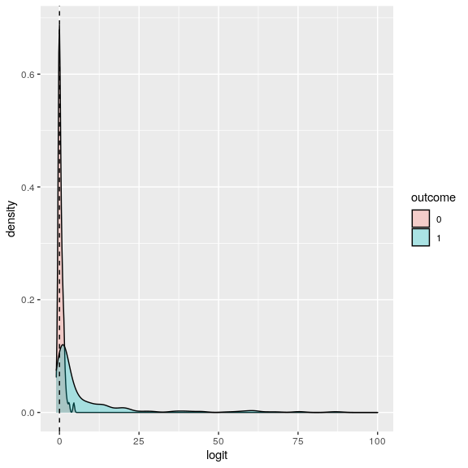

```r
esportb$logit <- predict(lrm)
esportb$outcome <- factor(esportb$y,levels=c("0","1"))
ggplot(esportb,aes(logit, fill=outcome))+geom_density(alpha=.3)+
  geom_vline(xintercept=0,lty=2) + xlim(-1, 100)
```

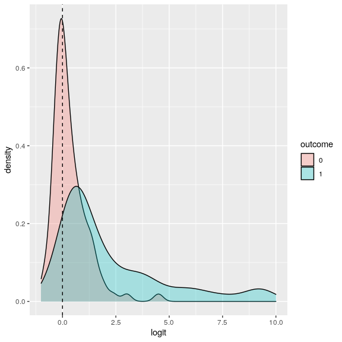

```r
ggplot(esportb,aes(logit, fill=outcome))+geom_density(alpha=.3)+
  geom_vline(xintercept=0,lty=2) + xlim(-1, 10)
```

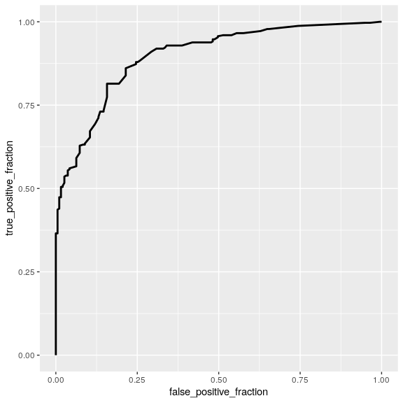

```r
library(plotROC)
ROCplot<-ggplot(esportb)+geom_roc(aes(d=y,m=prob), n.cuts=0)
ROCplot
```

```r
calc_auc(ROCplot)
```

```
##   PANEL group       AUC
## 1     1    -1 0.8969089
```

This AUC matches the AUC I got from using the class_diag() function. With this AUC value, I can say that this is a good model for predicting if the game is having `TotalEarnings` > 10000 based on the predictors of `Genre` and `TotalTournaments`.

## Using many predictors on Logistic Regression!

Now I predict if a game’s tournament will have `TotalEarnings` > 10000 based on the predictors: `Genre` + `TotalTournaments` + `OnlineEarnings` + `TotalPlayers` + `ReleaseDate`.

```r
lrm2 <- glm(y~ Genre + TotalTournaments + OnlineEarnings + TotalPlayers + ReleaseDate, data=esportb, family="binomial")
coeftest(lrm2)
```

```
##
## z test of coefficients:
##
## Estimate Std. Error z value Pr(>|z|)
## (Intercept) -2.5335e+02 8.8979e+01 -2.8473 0.0044086 **
## GenreCollectible Card Game -2.2343e+00 1.2659e+00
-1.7650 0.0775696 .
## GenreFighting Game -3.8127e+00 1.0701e+00 -3.5631
0.0003666 ***
## GenreFirst-Person Shooter -2.9173e+00 1.1149e+00 -2.6166
0.0088814 **
## GenreMultiplayer Online Battle Arena -1.0513e+00
1.2931e+00 -0.8129 0.4162470
## GenrePuzzle Game -3.3519e+00 1.4341e+00 -2.3373
0.0194251 *
## GenreRacing -2.0999e+00 1.1216e+00 -1.8722 0.0611793 .
## GenreSports -2.1021e+00 1.1777e+00 -1.7850 0.0742667 .
## GenreStrategy -1.6612e+00 1.0906e+00 -1.5232 0.1277048
## GenreThird-Person Shooter -1.5326e+00 1.5868e+00 -0.9658
0.3341221
## TotalTournaments -3.3037e-02 1.9073e-02 -1.7321
0.0832479 .
## OnlineEarnings 4.0542e-04 6.9283e-05 5.8517 4.865e-09
***
## TotalPlayers 5.4200e-02 1.1448e-02 4.7342 2.199e-06 ***
## ReleaseDate 1.2559e-01 4.4091e-02 2.8484 0.0043939 **
## ---
## Signif. codes: 0 '***' 0.001 '**' 0.01 '*' 0.05 '.' 0.1
' ' 1
```

```r
exp(coef(lrm2))
```

```
## (Intercept) GenreCollectible Card Game
## 9.337656e-111 1.070669e-01
## GenreFighting Game GenreFirst-Person Shooter
## 2.208878e-02 5.408055e-02
## GenreMultiplayer Online Battle Arena GenrePuzzle Game
## 3.494975e-01 3.501839e-02
## GenreRacing GenreSports
## 1.224739e-01 1.221980e-01
## GenreStrategy GenreThird-Person Shooter
## 1.899054e-01 2.159674e-01
## TotalTournaments OnlineEarnings
## 9.675030e-01 1.000406e+00
## TotalPlayers ReleaseDate
## 1.055695e+00 1.133815e+00
```

```r
prob2 <- predict(lrm2,type="response")
table(predict=as.numeric(prob2>.5),truth=esportb$y)%>%addmargins
```

```
##        truth
## predict   0   1 Sum
##     0   178  22 200
##     1    13 301 314
##     Sum 191 323 514
```

```r
class_diag(prob2,esportb$y)
```

```
##         acc      sens      spec       ppv       auc
## 1 0.9319066 0.9318885 0.9319372 0.9585987 0.9848929
```

The Accuracy is 0.9319066. The Sensitivity (TPR) is 0.9318885. The Specificity (TNR) is 0.9319372. The Precision (PPV) is 0.9585987. The AUC is 0.9848929. This means that this is a great model for predicting if the game is having `TotalEarnings` > 10000.

## 10-fold CV!

```r
set.seed(1234)
k = 10


data <- esportb[sample(nrow(esportb)),]
folds <- cut(seq(1:nrow(esportb)),breaks=k,labels=F)

diags <- NULL
for(i in 1:k){
train <- data[folds!=i,]
test <- data[folds==i,]

truth <- test$y

fit <- glm(y ~ Genre + TotalTournaments + OnlineEarnings + TotalPlayers + ReleaseDate, data=train, family="binomial")
probs <- predict(fit, newdata = test, type="resp")

diags <- rbind(diags,class_diag(probs,test$y))
}

summarize_all(diags,mean)
```

```
##         acc      sens      spec       ppv       auc
## 1 0.9183635 0.9225357 0.9147702 0.9451259 0.9814307
```

The AUC from the original model was 0.9848929. After 10-fold CV, the AUC is 0.9814307, which is a slight decrease. Since the model is still great and the difference is quite small, I conclude that this model does not show signs of overfitting.

The average out-of-sample classification diagnostics are: The Accuracy is 0.9183635. The Sensitivity (TPR) is 0.9225357. The Specificity (TNR) is 0.9147702. The Precision (PPV) is 0.9451259.

## LASSO!

```r
library(glmnet)
set.seed(1234)

z <- as.matrix(esportb$y)
x <- model.matrix(z ~ Genre + TotalTournaments + OnlineEarnings + TotalPlayers + ReleaseDate, data=esportb)[,-1]
head(x)
```

```
## GenreCollectible Card Game GenreFighting Game
GenreFirst-Person Shooter
## 1 0 0 0
## 2 0 0 0
## 3 0 0 0
## 4 0 0 0
## 5 0 0 0
## 6 0 0 0
## GenreMultiplayer Online Battle Arena GenrePuzzle Game
GenreRacing GenreRole-Playing Game
## 1 0 0 0 0
## 2 0 0 0 0
## 3 0 0 0 0
## 4 0 0 0 0
## 5 0 0 0 0
```

[output cut: 16 more lines]

```r
cv <- cv.glmnet(x, z, family="binomial")
cv
```

```
##
## Call:  cv.glmnet(x = x, y = z, family = "binomial")
##
## Measure: Binomial Deviance
##
##        Lambda Measure      SE Nonzero
## min 5.907e-05  0.5192 0.08044      12
## 1se 1.365e-04  0.5994 0.07568      13
```

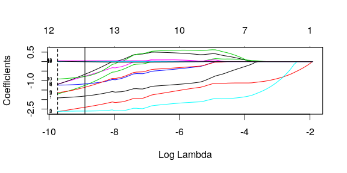

```r
{plot(cv$glmnet.fit, "lambda", label=TRUE); abline(v = log(cv$lambda.1se)); abline(v = log(cv$lambda.min),lty=2)}
```

```r
lasso <- glmnet(x, z, family="binomial", lambda=cv$lambda.min)
lasso
```

```
##
## Call: glmnet(x = x, y = z, family = "binomial", lambda =
cv$lambda.min)
##
## Df %Dev Lambda
## 1 12 68.6 5.907e-05
```

```r
coef(lasso)
```

```
## 15 x 1 sparse Matrix of class "dgCMatrix"
##                                                 s0
## (Intercept)                          -2.429475e+01
## GenreCollectible Card Game           -1.911546e+00
## GenreFighting Game                   -2.636135e+00
## GenreFirst-Person Shooter            -1.701535e+00
## GenreMultiplayer Online Battle Arena -1.234164e+00
## GenrePuzzle Game                     -2.618775e+00
## GenreRacing                          -1.188355e+00
## GenreRole-Playing Game                .
## GenreSports                          -1.204635e+00
## GenreStrategy                        -1.630908e+00
## GenreThird-Person Shooter            -9.095024e-01
## TotalTournaments                      .
## OnlineEarnings                        7.904838e-05
## TotalPlayers                          4.383062e-02
## ReleaseDate                           1.207549e-02
```

```r
lasso_dat <- esportb %>% mutate(CollectibleCardGame = ifelse(Genre=="Collectible Card Game", 1, 0) ) %>% mutate(FightingGame = ifelse(Genre=="Fighting Game", 1, 0) ) %>% mutate(FPS = ifelse(Genre=="First-Person Shooter", 1, 0) )%>% mutate(MOBA = ifelse(Genre=="Multiplayer Online Battle Arena", 1, 0) ) %>% mutate(PuzzleGame = ifelse(Genre=="Puzzle Game", 1, 0) ) %>% mutate(Racing = ifelse(Genre=="Racing", 1, 0) ) %>% mutate(Sports = ifelse(Genre=="Sports", 1, 0) ) %>% mutate(MOBA = ifelse(Genre=="Multiplayer Online Battle Arena", 1, 0) ) %>% mutate(MOBA = ifelse(Genre=="Multiplayer Online Battle Arena", 1, 0) ) %>% mutate(Strategy = ifelse(Genre=="Strategy", 1, 0) ) %>% mutate(TPS = ifelse(Genre=="Third-Person Shooter", 1, 0) ) %>% select(CollectibleCardGame:Racing, Sports:TPS, OnlineEarnings:ReleaseDate)
```

LASSO shows that all of the Genres and selected predictors (except `TotalTournaments`) have nonzero coeffient estimates. It is interesting that the lambda.min reduces the coefficients by 1 while lambda.1se retains all of the coefficients.

## 10-fold CV for LASSO!

```r
set.seed(1234)
k = 10


data <- esportb[sample(nrow(esportb)),]
folds <- cut(seq(1:nrow(data)),breaks=k,labels=F)

diags <- NULL
for(i in 1:k){
train <- data[folds!=i,]
test <- data[folds==i,]

truth <- test$y

fit <- glm(y ~ Genre + OnlineEarnings + TotalPlayers + ReleaseDate, data=train, family="binomial")
probs <- predict(fit, newdata = test, type="resp")

diags <- rbind(diags,class_diag(probs,test$y))
}

summarize_all(diags,mean)
```

```
##         acc      sens      spec       ppv       auc
## 1 0.9183635 0.9222326 0.9147702 0.9449871 0.9801063
```

## Conclusion

Overall, it was really interesting to model the data from the esports tournament data set. I created a great model for predicting if a given game will be highly prized based on these predictors: `Genre` + `TotalTournaments` + `OnlineEarnings` + `TotalPlayers` + `ReleaseDate`.